# Selva_3

```r
library(RCurl)
guns=read.csv(text=getURL("https://raw.githubusercontent.com/OscarFHC/NRE538_GSRA/master/Labs/NRE538_Lab2/guns.csv"), sep=",", header=T, comment.char="#")
```

```r
guns.MI = subset(guns, state=="Michigan")
t.test(guns.MI[,"murder"], mu=9)
```

```
##
##  One Sample t-test
##
## data:  guns.MI[, "murder"]
## t = 2.3794, df = 22, p-value = 0.02644
## alternative hypothesis: true mean is not equal to 9
## 95 percent confidence interval:
##   9.085973 10.253157
## sample estimates:
## mean of x
##  9.669565
```

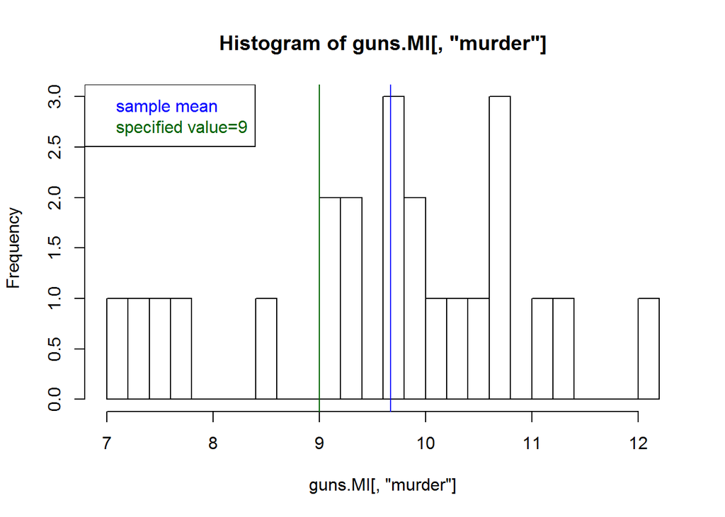

```r
hist(guns.MI[,"murder"], breaks=20)
abline(v=mean(guns.MI[,"murder"]), col="blue")
abline(v=9, col="dark green")
  legend("topleft", legend = c("sample mean", "specified value=9"),text.col=c("blue", "dark green"))
```

Exercise 1:

One-tail t-test:

Null: The violent crime rate in MI state is not significantly greater than 500 (per 10^5).

```r
t.test(guns.MI[,"violent"], mu=500, alternative='greater')
```

```
##
##  One Sample t-test
##
## data:  guns.MI[, "violent"]
## t = 11.611, df = 22, p-value = 3.733e-11
## alternative hypothesis: true mean is greater than 500
## 95 percent confidence interval:
##  666.343     Inf
## sample estimates:
## mean of x
##   695.213
```

We can reject the null hypothesis that the violent crime rate is not greater than 500 (per 10^5) because our p-value is 3.733e-11. Therefore, we can safely conclude that the violent crime rate is greater than 500 (per 10^5).

Two-tailed t-test:

Null: The robbery rate of MI state is equal to 400 (per 10^5).

```r
t.test(guns.MI[,"robbery"], mu=400, alternative = 'two.sided')
```

```
##
##  One Sample t-test
##
## data:  guns.MI[, "robbery"]
## t = -17.072, df = 22, p-value = 3.538e-14
## alternative hypothesis: true mean is not equal to 400
## 95 percent confidence interval:
##  213.7522 254.1000
## sample estimates:
## mean of x
##  233.9261
```

We can reject the null hypothesis that the robbery rate in MI is equal to 400 (per 10^5) because our p-value is 3.538e-14. Therefore, we can safely conclude that the robbery rate in MI is different from 400 (per 10^5).

END EXERCISE 1

```r
guns.WAS = subset(guns, state=="Washington")
guns.MIN = subset(guns, state=="Minnesota")
t.test(guns.WAS[,"murder"], guns.MIN[,"murder"], paired=FALSE)
```

```
##
##  Welch Two Sample t-test
##
## data:  guns.WAS[, "murder"] and guns.MIN[, "murder"]
## t = 12.104, df = 43.616, p-value = 1.546e-15
## alternative hypothesis: true difference in means is not equal to 0
## 95 percent confidence interval:
##  1.753891 2.454804
## sample estimates:
## mean of x mean of y
##  4.773913  2.669565
```

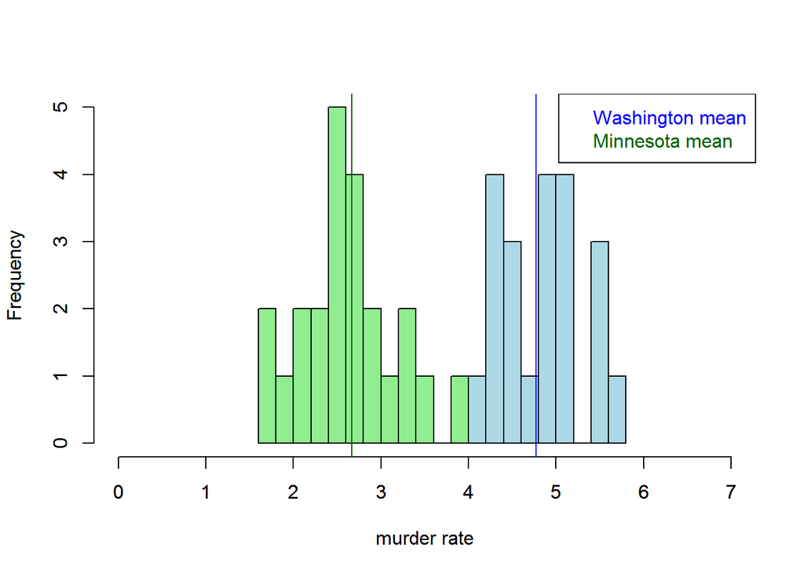

```r
hist(guns.WAS[,"murder"], breaks=15, col="light blue", xlim=c(0, 7), ylim=c(0,5), xlab="murder rate", main="")
abline(v=mean(guns.WAS[,"murder"]), col="blue")
par(new=TRUE)
hist(guns.MIN[,"murder"], breaks=15, col="light green", xlim=c(0, 7), ylim=c(0,5), xlab="", main="")
abline(v=mean(guns.MIN[,"murder"]), col="dark green")
  legend("topright", legend = c("Washington mean", "Minnesota mean"),text.col=c("blue", "dark green"))
```

```r
shapiro.test(guns.WAS[,"murder"])
```

```
##
##  Shapiro-Wilk normality test
##
## data:  guns.WAS[, "murder"]
## W = 0.94148, p-value = 0.1933
```

```r
shapiro.test(guns.MIN[,"murder"])
```

```
##
##  Shapiro-Wilk normality test
##
## data:  guns.MIN[, "murder"]
## W = 0.98013, p-value = 0.9083
```

```r
var.test(guns.WAS[,"murder"], guns.MIN[,"murder"])
```

```
##
##  F test to compare two variances
##
## data:  guns.WAS[, "murder"] and guns.MIN[, "murder"]
## F = 1.2072, num df = 22, denom df = 22, p-value = 0.6626
## alternative hypothesis: true ratio of variances is not equal to 1
## 95 percent confidence interval:
##  0.5119867 2.8464432
## sample estimates:
## ratio of variances
##           1.207204
```

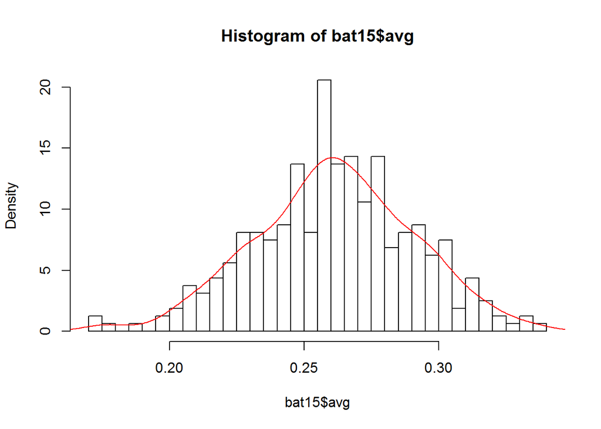

```r
library(Lahman)
data(Batting)
bat15 = subset(Batting, yearID==2015 & AB>200)
bat15$avg = bat15$H/bat15$AB
hist(bat15$avg, breaks=30, freq=FALSE)
lines(density(bat15$avg), col="red")
```

```r
shapiro.test(bat15$avg)
```

```
##
##  Shapiro-Wilk normality test
##
## data:  bat15$avg
## W = 0.99669, p-value = 0.7514
```

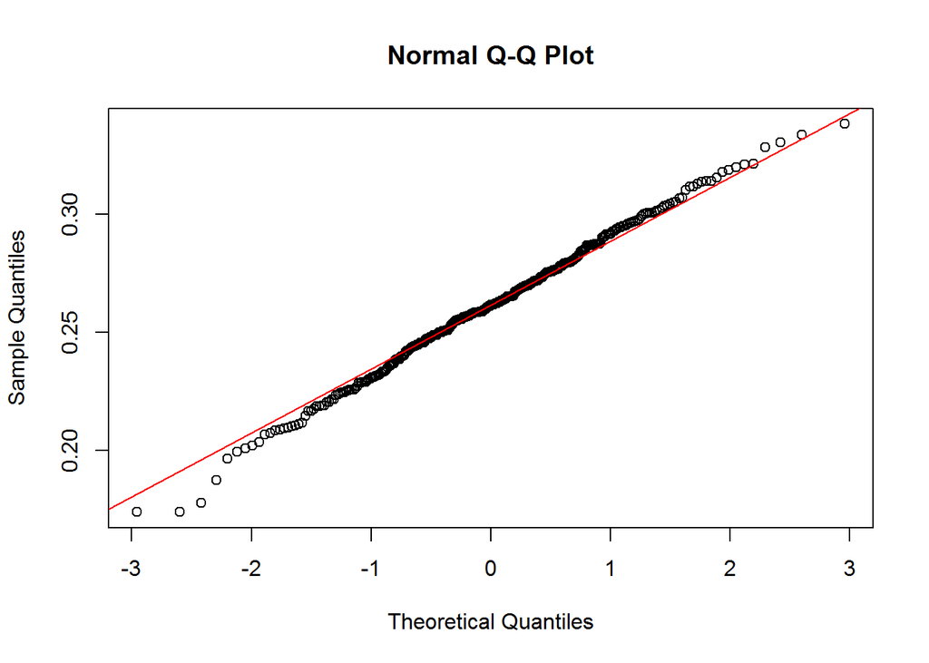

```r
qqnorm(bat15$avg); qqline(bat15$avg, col="Red")
```

```r
se=sd(bat15$avg)/(sqrt(length(bat15$avg)))
mean.avg=mean(bat15$avg)
upper=mean(mean.avg)+qnorm(0.975)*se
lower=mean(mean.avg)-qnorm(0.975)*se
```

```r
muA=4
sdA=1
set.seed(32)
A = rnorm(30, mean=muA, sd=sdA)
A.mean=mean(A)

A.mean.SE=sqrt(var(A)/length(A))
A.mean.CI=c(A.mean-qnorm(0.975)*A.mean.SE, A.mean+qnorm(0.975)*A.mean.SE)
A.mean.CI
```

```
## [1] 3.946952 4.459307
```

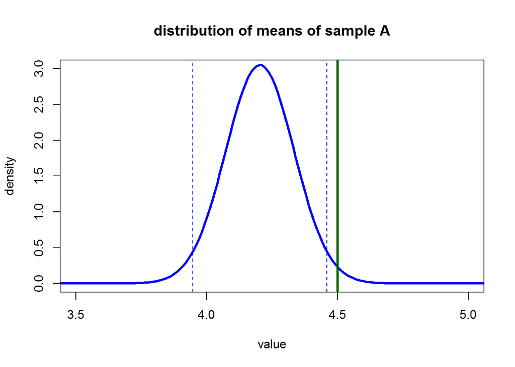

```r
xs = seq(0, 15, by =0.01)
fA = dnorm(xs, mean=A.mean, sd=A.mean.SE)
plot(fA~xs, type="l", lwd=3, col="blue", xlim=c(3.5, 5), ylim=c(0, 3),
     main="distribution of means of sample A", xlab="value", ylab="density")
abline(v=c(qnorm(0.025, mean=A.mean, sd=A.mean.SE), qnorm(0.975, mean=A.mean, sd=A.mean.SE)), col="blue", lty="dashed")
abline(v=4.5, col="dark green", lty="solid", lwd=3)
```

```r
p.m=2*(1-pnorm(4.5, mean=A.mean, sd=A.mean.SE))
p.m
```

```
## [1] 0.02312896
```

```r
t.test(A, mu=4.5)$p.value
```

```
## [1] 0.03073017
```

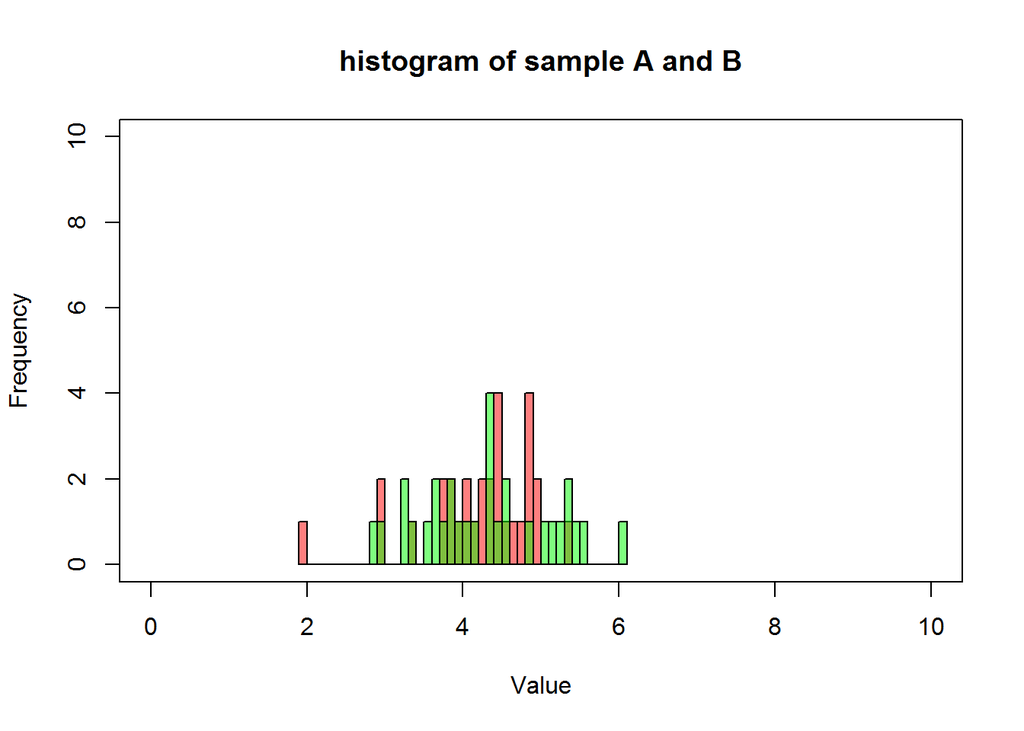

```r
muA=4
muB=4.5
sdA=1
sdB=1
set.seed(32)
A = rnorm(30, mean=muA, sd=sdA)
B = rnorm(30, mean=muB, sd=sdB)
hist(A,breaks=30,col=rgb(1,0,0,0.5),xlim=c(0,10), ylim=c(0,10), xlab="Value", main="histogram of sample A and B")
hist(B,breaks=30,col=rgb(0,1,0,0.5),add=TRUE)
box()
```

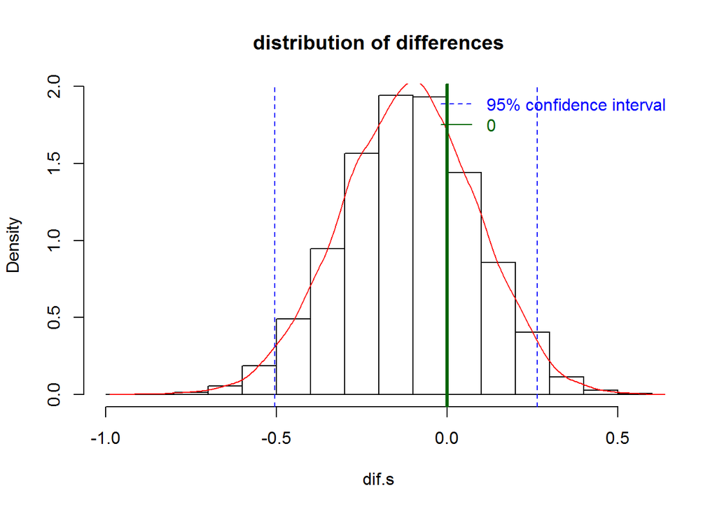

```r
set.seed(9487)
dif.s=c() # creating an empty vector to store the "differences" in the for loop
for (i in 1:10000){
  dif.s[i]=mean(sample(A, 30, replace=TRUE)) - mean(sample(B, 30, replace=TRUE))
}
dif.s.mean = mean(dif.s)
dif.s.sd = sd(dif.s)
CI95.lo = sort(dif.s)[10000*0.025]
CI95.hi = sort(dif.s)[10000*0.975]

hist(dif.s, probability=TRUE, main="distribution of differences")
lines(density(dif.s), col="red")
abline(v=c(CI95.lo, CI95.hi), col="blue", lty="dashed")
abline(v=0, col="dark green", lty="solid", lwd=3)

legend("topright", legend = c("95% confidence interval",
                              "0"),
       col=c("blue", "dark green"),
       text.col=c("blue", "dark green"),
       lty=c("dashed", "solid"), bty="n")
```

```r
2*(length(which(dif.s>0))/length(dif.s))
```

```
## [1] 0.5712
```

```r
t.test(A, B, paired = FALSE)
```

```
##
##  Welch Two Sample t-test
##
## data:  A and B
## t = -0.55121, df = 56.76, p-value = 0.5837
## alternative hypothesis: true difference in means is not equal to 0
## 95 percent confidence interval:
##  -0.5113621  0.2906234
## sample estimates:
## mean of x mean of y
##  4.203129  4.313499
```

Exercise 2:

Null: The murder rate of Washington state is not significnatly different from that of Minnesota state.

First, we must make sure that assumptions are to run the -test are met: 1) the variances are equal, and 2) the samples are normally distributed.

Test of Variances:

```r
var.test(guns.WAS[,"murder"], guns.MIN[,"murder"])
```

```
##
##  F test to compare two variances
##
## data:  guns.WAS[, "murder"] and guns.MIN[, "murder"]
## F = 1.2072, num df = 22, denom df = 22, p-value = 0.6626
## alternative hypothesis: true ratio of variances is not equal to 1
## 95 percent confidence interval:
##  0.5119867 2.8464432
## sample estimates:
## ratio of variances
##           1.207204
```

Test of Normality:

```r
shapiro.test(guns.WAS[,"murder"])
```

```
##
##  Shapiro-Wilk normality test
##
## data:  guns.WAS[, "murder"]
## W = 0.94148, p-value = 0.1933
```

```r
shapiro.test(guns.MIN[,"murder"])
```

```
##
##  Shapiro-Wilk normality test
##
## data:  guns.MIN[, "murder"]
## W = 0.98013, p-value = 0.9083
```

T-test:

```r
t.test(guns.WAS[,"murder"], guns.MIN[,"murder"], paired=FALSE, var.equal=TRUE)
```

```
##
##  Two Sample t-test
##
## data:  guns.WAS[, "murder"] and guns.MIN[, "murder"]
## t = 12.104, df = 44, p-value = 1.347e-15
## alternative hypothesis: true difference in means is not equal to 0
## 95 percent confidence interval:
##  1.753979 2.454717
## sample estimates:
## mean of x mean of y
##  4.773913  2.669565
```

END EXERCISE 2